# Square Fireballs RPG

## Welcome to the game

Welcome to Square Fireballs! In this game, a group of friends can take the role of a party of adventurers exploring a fantasy world, fighting rampaging monsters, and discovering ancient treasures.

We recommend playing this game in groups of 4 to 6 players.

### What is a Role Playing Game?

Square Fireballs is a Role Playing Game, that is, a game where players use their imagination to represent characters in a simulated world. Players sit on a table, and use rulebooks, pen, paper and dice to resolve character actions and keep track of game progress.

There are two types of players in these games:

- **Player Characters**: Each Player Character (abreviated as **PC**) has a character with their own unique backgrounds, personalities, and sets of skills. Player Characters get to decide what actions their characters take, but not necessarily the outcomes of these actions - those are determined by the rules of the game and usually involve a random element like dice.
- **Game Master**: The Game Master, or **GM**, is in control of the game world: its environments and history, and all characters other than the Player Characters (which are known as **Non-Player Characters**, or **NPCs**). The Game Master’s responsibility is to present interesting scenarios and challenges for the players to overcome. In each game session there must be one Game Master.

A Role Playing Game is composed of a set of **game rules**, which provide a framework to resolve the character’s actions and their interactions with each other and with the game world. Another component that is often present is a description of the **game setting**: the people and places that PCs can interact with. This is used as a reference by GM and PCs alike to better understand what is going on in the game, and how their characters should behave. In addition, many games also include suggestions on how to run a game, explanations of the game philosophy, and other pieces of advice.

Role Playing games are usually played in **game sessions** of a few hours of duration. Player groups that meet regularly can have a persistent continuity across game sessions, following the adventures of a cast of recurring characters over extended periods of time - this is known as a **game campaign**.

Unlike board games and most computer games, Role Playing Games do not have a fixed set of goals or win conditions. Rather, a GM presents Player Characters with a series of scenarios, often involving but not limited to the resolution of missions and quests. The Player Characters are not obligated to achieve these missions, but are encouraged to do in order to aquire wealth and fame within the game world (or, more rarely, out of sheer nobility and heroism). On the other hand, it is quite possible for characters to die in the game, and a party of PCs can, in fact, lose the game once if all their characters are dead. It should be noted, though, that although the GM is in control of the PCs’ enemies, a GM’s goal in the game is not to defeat the PCs, but to present them with challenging encounters, to enforce the game rules with fairness, and to make the game as fun as possible for everyone. Some characters may not survive the experience.

### Why Square Fireballs?

Why did we choose to call our game Square Fireballs? What does that even mean? The following figures illustrate the reasoning behind the name:

[figure not shown]

In this game, whenever a combat encounter comes up, characters are arranged on a gridded map in order to keep track of their relative positions. This can be done by using miniatures to represent each character, or other means such as cardboard tokens. The grid map is composed of **squares** - each square being the minimum unit of distance in the game. Typically, a single character can fit on a given square. Each character can move a certain number of squares during a game turn, and make melee attacks to enemy characters in adjacent squares. A character’s ranged attacks have a maximum range measured in squares. Diagonal movement across squares in the map is handled just the same as horizontal or vertical movement - just count the number of squares crossed - , which introduces some interesting distortions to the map geometry. And this brings us back to the figures above, and the Square Fireballs.

You see, this is a game set in a fantasy world where heroic adventurers such as fighters, rogues and wizards battle hordes of monsters such as orcs and goblins. The figure to the left depicts a wizard (leftmost square) facing four goblins and an orc (to the right). Now, wizard characters are famous for their ability to conjure offensive spells to blast groups of enemies. The right figure shows one such spell, a Lesser Fireball, centered on the unfortunate orc, and producing an explosion that damages everything in adjacent squares - including the orc’s four goblin buddies. Observant readers will note that, due to the geometrical liberties we have taken in our choice of map representation, said Ball of Fire is rendered as a perfect square. Someone found this funny enough to use it as the name for a blog and, years later, decent enough to reuse as the title of a game.

And this is why the cover of the game says Square Fireballs, and why goblins don’t like to walk close to each other.

### Why should you play this game?

In the decades since the invention of role playing games, there have been plenty of game systems based on the same basic concept of adventuring in a fantasy world. Many of them are great. Some introduce highly innovative ideas in their rules or settings. Most of them are prettier than the one you hold in your hands. Why, then, should you keep reading this?

The defining features of Square Fireballs are rich tactical combat, flexible and straightforward rules for non-combat interactions, and easy preparation of game sessions and characters. Of these, the star of the show is the combat. It is a deep system that rewards careful positioning, teamwork, and resource management. It offers a great deal of variety, in options for building and playing characters, in the range of available monsters, and in ways of interacting with the environment. And yet, I have taken great effort in making the rules accessible and consistent, in removing any complexity over the strictly necessary, and in ensuring that no style of play is overshadowed by others.

The rules for handling challenges outside of combat are a different beast altogether. All interactions share the same simple resolution mechanic, and there are always multiple paths to achieve an objective. Creative thinking, planning and collaboration are rewarded, and there are clear guidelines for handling failures and allowing the game to move forward.

Finally, the game goes to great lengths to reduce the effort and difficulty of setting up a session. Characters are highly customizable, but players are always offered a default option, and all choices are close enough in effectiveness that even choosing at random should result in a competent and enjoyable adventurer. Monsters are likewise easy to customize, and random generation of monsters and encounters is both supported and encouraged. Characters have levels that determine their overall power, but the progression is smooth enough that adventurers and monsters of a wide range of levels can take part in the same combat in a satisfying way.

It’s only fair to mention that Square Fireballs is not a perfect system, nor is it a game for everybody. There is a strong emphasis in combat, and while I believe that the non-combat mechanics are solid enough, players that are not interested in fighting monsters will be missing a huge part of the system. The design prioritizes gameplay over realism, and players that look for accurate simulations of fantastical societies and ecosystems will probably not find what they are looking for in here. And the game lacks an actual setting, and leaves Game Masters to borrow their world descriptions from other sources - though, on the bright side, it has been designed to be quite flexible in that regard, and be able to fit in anything from high fantasy to nonmagical medieval adventure.

All of these disclaimers aside, I honestly believe there is a great time to be had in here. If you are at all excited by the notion of incinerating goblins, pushing ogres off cliffs, triggering trapped chests, grappling with dragons, finding legendary swords, talking to mysterious strangers in taverns, arguing with kings, leaping from the shadows, performing miracles, getting stabbed, bitten, cursed, imprisoned, poisoned, petrified, swallowed whole… If any of these sound like fun, read on.

## A note on text format

We use different styles of text to differentiate between game rules and definitions, and other types of content. Here is a quick summary:

Normally formatted, black text is used to describe game rules.

*Italics are used to provide non-mechanic related descriptions: flavor, backstory.*

```
Text in white boxes is used to define formulas.
```

Blue text is used to provide advice on how to play the game. It is typically preceded by **“Tip”** or **“Example”**.

Gold text is used to provide compatibility instructions to integrate material from older sourcebooks. It is typically preceded by **“Compatibility Note”**.

Red text is used to provide insight into the designer’s ideas regarding a game element. It is typically preceded by **“Designer’s Note”**.

## Rolling Dice

For any non-trivial action that a character performs in the game, success is not guaranteed. We use dice to determine the outcomes of these actions. There are three main types of dice rolls in the game:

- **Checks**: Used to determine whether an action is a success or a failure.
- **Damage Rolls**: Used to determine the amount of damage (or, more rarely, of healing) that a character takes.
- **Action Point Rolls**: Used to determine if a character can use an Action Point.

Square Fireballs, like many role playing games, uses special dice with different number of sides:

- Twenty-sided dice, or d20
- Four-sided dice, or d4
- Six-sided dice, or d6
- Eight-sided dice, or d8
- Ten-sided dice, or d10
- Twelve-sided dice, or d12

D20s are always used for Checks. D4s are used for Action Point Rolls. Damage rolls can use d4s, d6s, d8s, d10s or d12s - the specific dice used by a character at any given type depends on that character’s choice of weapons and powers.

Sometimes the game requires a player to roll severall dice at once as part of a damage roll. In these cases, the number of dice is written before the type of dice. This way, 2d6 means rolling two six-sided dice, whereas 5d10 means rolling five ten-sided dice, and 9d4 means rolling nine four-sided dice. When a single die is rolled, no number is required: d12 means rolling one twelve-sided die.

The type of dice required for a damage roll in an attack made with a weapon can vary depending on the weapon used. Longswords use d8s, whereas Greatswords use d12s, daggers use d4s, and so forth. In the game, we use ‘W’ to refer to the damage dice of a weapon attack: W means one die, 2W means two dice, 3W means three dice, and so on. When making an attack with a weapon, replace the W with the appropriate type of dice used by that weapon: A ‘W’ attack with a Longsword rolls d8, a ‘2W’ attack with a Greatsword rolls 2d12, and a ‘7W’ attack with a dagger rolls 7d4.

### Rolling Checks

There are several types of checks in the game that a character can make:

- **Attack Rolls**: Used to determine whether an attack hits or misses. Rolled as part of an Attack Action.
- **Skill Checks**: Used to determine whether an interaction with other characters or the environment is a success or a failure. Rolled as part of a Skill Action.
- **Saves**: Used to resist a harmful condition. Some effects allow characters to automatically attempt a Save at the end of their turns. These are known as ‘Save Ends’ effects. In addition, some powers allow a character to Save against certain effects.

The general method to resolve a check is to roll a d20, add the character’s bonus to that check (if any) and any modifiers that apply, and compare the result with a target number. If the result is equal or greater than the target number, the check is a success, otherwise, the check is a failure.

- For Attack Rolls, the attacking character rolls a d20, adds the character’s Hit bonus for that attack and any attack modifiers that apply, and compares the result with the defending character’s Defense attribute that is appropriate for that attack. There are four different defense attributes: Armor (Ar), Fortitude (For), Reflex (Ref) and Will (Wil). This process is described in more detail in the Combat chapter.
- For Skill Check, the character making the check rolls a d20, adds the character’s Skill bonus for the Skill used in that action, and any modifiers that apply. The result is compared with a number based on the Skill Check Difficulty. This process is described in more detail in the Skills chapter.
- For a Save, the character making the save rolls a d20, and adds any modifiers that apply. If the result is equal to or greater than 11, the Save succeeds, otherwise it is a failure. This process is described in more detail in the Combat chapter.

## Character Stats

In this section, we describe the main stats that affect the performance of characters (including both Player Characters and Monsters) in the game.

### Level

The **Level** of a character is a general measure of that character’s relative power. Player Characters start at level 1, and gain levels as they acquire experience, up to a maximum of 30. Monsters have a level that is determined by their race, and is typically between 1 and 30, but can exceptionally go over 30.

The most direct benefit of Level is its impact on character attacks. Attacking a lower level character provides a bonus to hit of +1 per every two levels that the attacker has over the defender. Likewise, attacking a higher level character provides a hit penalty penalty of -1 per every two levels that the attacker has below the defender.

In addition, a character’s Hit Points are derived from character level (and class), and attack damage increases with level. For a detailed view of damage progression for Player Characters, see Levelling in the Character Building chapter. For a detailed view of damage progression for monsters, see Monster Stats in the Monster chapter.

Based on the level of Player Characters, the game is organized in three **tiers**: **Heroic** (levels 1 to 10), **Paragon** (levels 11 to 20) and **Epic** (levels 21 and above). Character tier is sometimes referenced by game elements such as feats, but otherwise has no direct impact on the game. For a detailed discussion of tiers, see Levelling in the Character Building chapter.

### Hit Points

Combat in the game is represented as a succession of attacks where characters deal a certain amount of damage to each other. **Hit Points** (abbreviated as **HP**) are a character stat that determines how much damage the character can take before falling unconscious.

The amount of HP of a Character depends on character Level and Class, for Player Characters, and on character Level, monster Role, and monster Type, in the case of monsters. The HP progression for Player Characters is:

- Classes with normal HP: 30 HP + 3 HP per level.
- Classes with high HP: 35 HP + 3.5 HP per level.
- Classes with very high HP: 40 HP + 4 HP per level.

A summary table with the HP and other stats corresponding to each Player Character class is provided in the Classes section of the Character Building chapter.

A character under half of their maximum Hit Points is said to be Bloodied. Many game effects check for the Bloodied condition in characters. For easier reference, a **Bloodied Value** stat is provided for each character, equal to one half of maximum Hit Points. Characters with a current HP total under Bloodied Value are Bloodied.

For Player Characters, another stat derived from Hit Points is the **Surge Value**, which determines the amount of HP that is healed when a character spends a Surge to heal. A character’s Surge Value is equal to one quarter their maximum Hit Points.

### Abilities

All characters have six Abilities, which are used for non-combat interaction such as Skill Checks and Ability Checks, as well as for combat maneuvers. For Player Characters, Abilities are often used to determine the effect of Powers and other attacks. The abilities are:

- **Strength (Str)**: Ability to exert force, perform physical feats
- **Constitution (Con)**: Ability to endure pain, make long efforts, concentrate.
- **Dexterity (Dex)**: Ability to move quickly and gracefully. Coordination.
- **Wisdom (Wis)**: Ability to know the environment, observe and anticipate. Intuition.
- **Charisma (Cha)**: Ability to communicate and persuade. Self-confidence.
- **Intelligence (Int)**: Ability to reason, memorize, learn.

Each Ability is a value, typically ranging between -1 and 5, which is applied as a modifier to Skill Checks, Ability Checks, and a variety of Power effects, with the exception of those dealing with damage and healing. For effects related to damage and healing of a Player Character, an Ability is adjusted by a level-dependent multiplier. This is called an Ability Damage Modifier.

For Player Characters, some stats that are derived from Abilities. These are the Secondary Defenses (Fortitude, Reflex, Will) and Secondary Stats (Reaction, Surges, and Initiative). These are the stats that correspond to each Ability:

- **Strength**: Fortitude, Reaction
- **Constitution**: Fortitude, Surges
- **Dexterity**: Reflex, Initiative
- **Wisdom**: Reflex, Reaction
- **Charisma**: Will, Surges
- **Intelligence**: Will, Initiative

The process for generating a Player Character’s Abilities is described in the Stat Generation section, in the Character Building chapter.

#### Ability Damage Modifier

As the level of characters increases, so do their Hit Points, the amount of damage they deal, and the amount of healing they require. To keep Ability modifiers relevant when applied to damaging and healing effects of a Player Character, we adjust them by a multiplier that depends on the character’s level. The Ability modifier multiplied by this value is called **Ability Damage Modifier**. There is an Ability Damage Modifier for each character Ability, and there are referred to as Strength Damage Modifier, Dexterity Damage Modifier, and so on.

| Level | Multiplier value |
| --- | --- |
| 1 | x1 |
| 3 | x1.5 |
| 9 | x2 |
| 11 | x2.5 |
| 14 | x3 |
| 17 | x3.5 |
| 19 | x4 |
| 21 | x4.5 |
| 24 | x5 |
| 27 | x5.5 |
| 29 | x6 |

An Ability Damage Modifier is applied instead of a regular Ability score in the following cases:

- Damage roll and extra damage
- Extra Miss Damage
- Damage modifier
- Damage penalty
- Shield Points (also known as Temporary Hit Points)
- Bonus to HP
- Bonus to Surge Value
- Healing or extra healing
- Regeneration

**Compatibility Note**: Some old powers use Ability Modifiers in combination with Resistances or Vulnerabilities. This is no longer supported - to see how this is translated to the current rules, see Resistances and Vulnerabilities in the Combat chapter.

### Defenses

A character’’s defenses determine how hard the character is to hit with attacks. Characters have one Primary Defense and three Secondary Defenses.

**Tip**: Defense values typically range between 10 and 17 for Player Characters, and between 11 and 15 for monsters. For all characters, the average defense value is 13, which corresponds to a 65% chance of being hit on an attack with the typical hit bonus of +5.

**Armor Class** (**AC**), is the Primary Defense, the one most commonly targeted by attacks. For Player Characters, AC is determined by the type of Armor and Shield worn by the character, plus a class-dependent bonus if the character is wearing Light Armor. The following formula is used while wearing Light Armor:

```
AC = 10 + Armor bonus + Shield bonus + Class Light Armor bonus
```

A Player Character wearing Heavy Armor uses the following AC formula instead:

```
AC = 10 + Armor bonus + Shield bonus
```

A table stating the AC bonuses for each type of Armor and Shield is provided in the Equipment section of the Character Building chapter. A table with the Light Armor bonuses and other class stats is provided in the Class section of the Character Building chapter.

For Monsters, AC is determined by monster class. A table with the typical AC values for each class role is provided in the Monster Stats section of the Monsters chapter.

The Secondary Defenses are **Fortitude** (For), **Reflex** (Ref) and **Will** (Wil). These defenses are used much less frequently than Armor Class: on average, all three Secondary Defenses put together are targeted roughly as much as AC. For Player Characters, each Secondary defense is determined by the character’s Ability scores, plus a bonus based on character class:

```
For = 10 + Class bonus to For + (highest of Str and Con)
Ref = 10 + Class bonus to Ref + (highest of Dex and Wis)
Wil = 10 + Class bonus to Wil + (highest of Cha and Int)
```

A table stating the Secondary Defense bonuses and other stats for classes is provided in the Class section of the Character Building chapter.

For Monsters, Secondary Defenses are determined by monster class. A table with the typical defense values for each class role is provided in the Monster Stats section of the Monsters chapter.

### Secondary Stats

In addition to their direct application as modifiers to Powers and Skill Checks, a Player Character’s Ability scores are used to generate six important stats: the three Secondary Defenses and three **Secondary Stats**. The Secondary Stats are **Reaction Modifier**, **Surge Number**, and **Initiative Modifier**.

**Reaction Modifier** is a hit modifier that applies to a character’s Spontaneous Reaction attacks. The most common type of Spontaneous Reaction attack is the Opportunity Attack, which is triggered by moving or making Ranged or Area attacks while adjacent to an enemy. Typical values for a Reaction Modifier range between -5 and +0. For Player Characters, a Reaction Modifier is determined as follows:

```
Reaction Modifier = (highest of Str and Wis) - 5
```

**Surge Number** is the maximum number of Surges that a Player Character can have. Characters can spend surges during an encounter to heal HP, and outside of encounters to have a Short Rest and recover all HP and Encounter powers. Characters regain all of their Surges after a Full Rest. Typical Surge Numbers range between 6 and 14. Each character class has a base value for Surge Number, which is modified by the character’s abilities:

```
Surge Number = Character Surges + (highest of Con and Cha)
```

**Initiative Modifier** is a value that is added to a character’s Initiative Roll at the start of an encounter, to determine the order in which character turns are taken. Typical values for an Initiative Modifier range between -3 and +5. Characters wearing armor may suffer an Armor Penalty, which is applied to the Initiative Modifier as well as to many Skills:

```
Initiative Modifier = (highest of Dex and Int) - Armor Penalty
```

Monster characters also have a Reaction Modifier and Initiative Modifier though, lacking Surges, they have no Surge Number. These stats are determined by monster class; a table with typical stat values for each class role is provided in the Monster Stats section of the Monsters chapter.

For a detailed discussion of Reactions, including the use of Spontaneous Reactions and application of Reaction Modifiers, see Reactions in the Combat chapter.

For more information about Surge usage and recovery, see Healing in the Combat chapter, and Resting in the Adventuring chapter.

For a description of Initiative Rolls, see Combat Sequence in the Combat chapter, and for a list of the different types of armor and their associated Armor Penalty, see Equipment in the Character Building chapter.

### Movement Speed

During an encounter, characters are assigned a position in a grid map, and they can take actions to move to new positions. The base movement distance that a character can move, measured in map squares, is called **Movement Speed**. This stat depends on the character’s race, and its value typically ranges between 4 and 7. Player Characters wearing Heavy Armor usually apply an Armor Movement Penalty of -1 to their Movement Speed:

```
Movement Speed = Race Speed - Armor Movement Penalty.
```

A summary table with the Race Speed and other stats corresponding to each Player Character race is provided in the Races section of the Character Building chapter. A table with the properties of different types of Armor and Shields, including Armor Movement Penalty, is provided in the Equipment section of the Character Building chapter.

Movement Speed is used for characters moving on the ground, which in the game world may translate into walking, running, crawling, oozing, rolling, or other exotic means of displacement. Some characters are capable of other forms of movement, such as flying or swimming, which have their own speed stats:

- **Flight Speed**, for creatures capable of flying.
- **Swimming Speed**, for aquatic creatures capable of swimming without a Skill check.
- **Burrowing Speed**, for moving by making tunnels in the ground or through walls.
- **Teleport Speed**, for creatures capable of teleporting between two squares within sight.

Whenever a game element refers to a character’s Speed, this applies to the Speed for any type of movement the character is using at the moment.

An in-depth discussion of different modes of movement is provided in the Movement section of the Combat chapter.

This chapter provides the rules for creating and levelling Player Characters. The overall character creation process is first described, and then each creation and levelling step is discussed in detail: stat generation, race and class selection, mundane equipment, feat selection, levelling up, and using magic items.

1. Overview
2. Stat Generation
3. Races
4. Classes
   - Paragon Paths
   - Epic Destinies
5. Equipment
6. Feats
7. Levelling
8. Magic Items

## Character Creation Overview

From the initial character concept to the point where the character sheet is complete, there are several decisions that a player must take in order to create a first level character. In this section, we explain the character creation process as a whole, and a more detailed discussion of each step is provided later on.

The basic steps for creating a character are:

1. Character concept and story
2. Race and Class selection
3. Ability generation
4. Skill selection
5. Equipment selection
6. Feat selection
7. Power selection
8. (Levelling)

**Tip**: Although beginning players are encouraged to follow the character creation steps in order as listed above, it is quite possible to go back and forth between steps, as each decision provides new inspiration and ideas to improve on previous choices. Furthermore, since the number of available options may get overwhelming for inexperienced (and not so inexperienced) players, we provide pre-built sample characters that can be played as-is, or used as basic templates to be customized to taste. These sample characters, along with suggested level-up options up to level 30, can be found in the Classes chapter.

## Ability generation

Once the player has decided on a character class and a class build, the abilities for the Player Character can be generated. To do this, the player first selects Primary, Secondary, and Weak Abilities, and then assigns scores to each Ability by picking one of two possible Ability Arrays.

By selecting Primary, Secondary, and Weak Abilities, a player chooses what will be the strong and weak points of the Player Character. These choices are usually conditioned, if not fully determined, by the character’s class and class build:

- The **Primary Ability** is the character’s strongest and most important Ability, used for most attacks. Most class builds have a fixed Primary Ability.
- The **Secondary Ability** adds useful bonuses to several character Powers and Class Features. Many class builds have a predetermined Secondary Ability, though some provide a choice between two or three options.
- The **Weak Ability** is an Ability that sees little to no use for the character, and has the lowest score. Class builds should provide suggestions for suitable Weak Abilities, but the choice is otherwise up to the player.

The remaining three Abilities are considered **Tertiary Abilities**.

The next step is to assign scores to each Ability. To this end, there are two **Ability Arrays** that can be chosen: a **Focused Array** that concentrates on maximizing the Primary Ability (and hence the character’s offensive potential), and a **Flexible Array** that provides a more balanced approach (resulting in a better Secondary Ability and higher average Secondary Defenses, Secondary Stats and Skills). The arrays assign the following scores to each Ability:

- Focused Array
  - +5 to Primary Ability
  - +2 to Secondary Ability
  - +0 to Tertiary Abilities
  - -1 to Weak Ability
- Flexible Array
  - +4 to Primary Ability
  - +3 to Secondary Ability
  - +1 to Tertiary Abilities
  - +0 to Weak Ability

**Tip**: When deciding over an Ability Array, the Focused Array is a safe default option, whereas the Flexible Array can shine for characters whose Class Features and Powers strongly reward high Secondary Abilities.

As a final step in the generation of Abilities, the player has to check the Favoured Abilities for the character’s Race. Each Race typically has two or more Favoured Abilities, and characters whose Favoured Abilities match their Primary or Secondary Abilities gain Skill-related bonus:

- If either the Primary Ability or the Secondary Ability match a Favoured Ability, the character gains Skill Training as a bonus Feat.
- If both the Primary Ability and the Secondary Ability match Favoured Abilities, the character gains Skill Training and Skill Focus as bonus Feats.

See the Feat section later in this chapter for a description of these bonus Feats. The player can choose any legally available Skill for these Feats, and should do so after choosing class and racial Skills for the character (as described in the Skills section in this chapter).

**Tip**: It is a good idea to take into account how racial Favoured Abilities match with the Primary and Secondary Abilities of each class build, when picking your Race and Class. However, if you really like a particular Race and Class combination with mismatched Abilities, you should not hesitate to take it - the Skill bonuses are a nice thing to have, but they won’t make or break a character.

**Compatibility Note**: The Favoured Ability rule replaces racial Ability bonuses from older rulebooks. When a race provides a bonus to one or more Abilities, consider instead that these Abilities are Favoured Abilities.

**Tip**: Character Abilities remain constant across all levels, with a few exceptions. It is possible to increase Tertiary and Weak Abilities by taking certain high level Feats. As for Primary and Secondary Abilities, the only way to increase them is by taking specific Epic Destinies.

**Compatibility Note**: Under previous rules for levelling characters, Abilities increased naturally upon reaching certain levels. Ignore any mention to such Ability increases. In addition, whenever an Epic Destiny from an older rulebook provides a bonus to an Ability score, that bonus is halved (typically from +2 to +1).

## Skill selection

Depending on their class, Player Characters can choose a number of Skills to become Trained in them. Characters gain a +3 bonus to Skill Checks with Trained Skills, and Skill Checks of Hard Difficulty are only available to characters with training in that Skill.

In order to select a Player Character’s Skills, the player should look look at the Class Skill List for the character’s class, as well as the Racial Skill List for the character’s race. Any Skill in either of these lists can be selected as a Trained Skill for the character. The player then looks at the number of Trained Skills allowed by the character’s class, and selects that many Trained Skills.

**Compatibility Note**: The Racial Skill rule replaces racial Skill bonuses from older rulebooks. When a race provides a numeric bonus to one or more Skills, consider instead that these Skills are Racial Skills. Any other Skill-related benefit, such as gaining Training with a specific Skill, remains unchanged.

Some Races and Classes provide automatic training with predetermined Skills. In that case, the character first gains training with these skills, and then the player selects Trained Skills as usual.

A character whose Primary or Secondary Abilities match their racial Favored Abilities gains bonus Skill-related Feats. The Skills associated with these Feats are chosen after the selection of Trained Skills.

**Tip**: When selecting Trained Skills, it is usually a good idea to prioritize Skills that match the character’s Primary or Secondary Abilities. If you end up with training in two or more Skills associated with your Tertiary or Weak Abilities, consider taking Unnatural Ability as a Lesser Feat when you level up, in order to compensate for the lower Ability scores in these Skills.

**Tip**: As your character levels up, you can expand your Trained Skill selection by taking Skill Training as a Lesser Feat. Alternatively, you can specialize on your best Skills by taking Skill Focus as a Lesser Feat.

For a detailed description of Skills and how to use them in the game, see the Skills section in the Adventuring chapter.

## Equipment selection

A character’s class determines which weapons, implements and armor the character is proficient with. Upon creation, every character starts the game with the following items: Up to three weapons the character is proficient with. An armor the character is proficient with. Up to one implement the character is proficient with.

In addition, starting characters get mundane equipment that has no impact on their stats and powers, including clothing, adventuring supplies, food, and money. The specific details should vary based on the character’s background and the context of the initial adventure, and be the result of a dialogue between player and Game Master. We suggest, by default, providing characters with food for a week of travel, money to cover living for a month, and a non-exhaustive list of items to carry with them, such as bedrolls, rope, and torches. In addition, whenever a more unusual item of reasonable weight and cost is needed, we recommend the Game Master to assume that a character is carrying it, provided that the player can come up with a convincing explanation.

**Designer Note**: Some games aim to provide a detailed simulation of economy in a fantasy world. This is not such a game. We believe that keeping track of the specific contents of a player’s backpack or the balance of each economic transaction are not critical to the game experience. Instead, we recommend players and Game Masters to keep inventories vague and flexible, outside of player rewards like Magic Items, or items of special importance to the game plot.

That said, if you favor more detailed rules for economy, there are tables with recommended item costs and weights from other game systems, such as D20SRD (http://www.d20srd.org/indexes/equipment.htm )and 13AGESRD (http://www.13thagesrd.com/equipment ), which are freely available online. You can use these tables as a reference for setting item prices in your campaign.

In the rest of this section, we list the weapons, armor and implement available in the game, along with a description of their rules.

### Weapons

Each weapon in the game is described by the following elements:

- **Name**
- **Family**: A category of weapons with similar properties. For example, Axes is a weapon family that includes hand axes, battle axes, and greataxes.
- **Damage**: Base damage dealt per weapon damage die.
- **Keywords**: Special properties associated with the weapon.
- **Training**: How much training is required to wield the weapon, determines which classes can use it.
- **Type**: Whether it is a Melee or Ranged weapon.
- **Hands**:Whether the weapon requires 1 or 2 hands to be wielded.

A character’s class determines which weapons the character is trained to use. A character using a weapon without training does not benefit from any of the weapon’s properties, including damage, keywords, and any magic abilities. Instead, the weapon is treated as an Light Improvised Weapon if it requires one hand to wield, or a Heavy Improvised Weapon if it requires two hands. Improvised weapons can be used without training.

**Compatibility Note**: In older rulebooks, weapon training is referred to as weapon proficiency, and weapons can have a Proficiency Bonus to hit, if the character is trained with them. This Proficiency Bonus no longer exists, and any mentions to it should be ignored.

#### Weapon Families

The following weapon families are supported in the game:

- **Axe**: Melee weapon consisting of a heavy edged head and a handle.
- **Bow**: Ranged weapon consisting of a strip of wood or other flexible material and a string, used to shoot arrows.
- **Crossbow**: Ranged weapon consisting on a bow mounted on a stick and a mechanism to hold the string. Used to shoot bolts.
- **Flail**: Melee weapon consisting on a blunt or spiked head attached to a handle by a chain or rope.
- **Hammer**: Melee weapon consisting of a heavy blunt head and a handle.
- **Heavy Blade**: Melee weapon with a long and heavy blade
- **Improvised**: A common object used as a weapon, or a weapon used without training.
- **Light Blade**: Melee weapon with a short or slender blade
- **Sling**: Ranged weapon consisting of a pouch and a string, used to throw stones or bullets.
- **Spear**: Melee weapon consisting of a pointed head attached to a long shaft.
- **Staff**: Melee weapon consisting of a long wooden shaft.
- **Unarmed**: A character’s own body used as a melee weapon.

**Tip**: Weapon Family is of special relevance in relation to the Weapon Focus category of Feats, as these Feats often give bonuses when wielding any weapon of a specific family. Advanced players are encouraged to study the different Feat bonuses when considering their weapon of choice. For beginning players, we suggest instead to choose based on aesthetic preferences - you can always use the Retraining rule to rethink your choice at a later point.

#### Weapon Keywords

The following weapon keywords are supported in the game:

- **Off-Hand**: The weapon can be wielded in the off-hand while another weapon or object is wielded in the main hand. When a character is simultaneously wielding two Off-Hand weapons, these weapons gain the Parry keyword (+1 AC vs melee).
- **Parry**: A character wielding one or more weapons with Parry gains +1 to AC against melee attacks. The bonus from multiple weapons with this keyword does not stack.
- **Range**: Ranged weapons have the Range keyword, followed by two numbers. The first number is the Short Range, the maximum distance at which the weapon can make Ranged and Area attacks without penalty. The second number is the Long Range, the maximum distance at which the weapon can make Ranged and Area attacks with a Long Range penalty (-2 hit).
- **Reach**: Weapons with reach increase the Melee Reach for attacks made with them by a certain amount. A medium-sized character typically has a Melee Reach of 1, which increases to 2 with a Reach +1 weapon, and to 3 with a Reach +2 weapon.
- **Recharge**: -2 to hit unless the wielder has spent a move action to recharge this weapon since last drawing it or attacking with it. – Recharge (move action). Move 1 square. You can ignore the Recharge penalty to hit with one of your weapons for your next attack power with that weapon.
- **Throw**: Melee weapons with Throw can be used to make Ranged and Area attacks as well as Melee and Close attacks. The Throw keyword is followed by two numbers. The first number is the Short Range, the maximum distance at which the weapon can make Ranged and Area attacks without penalty. The second number is the Long Range, the maximum distance at which the weapon can make Ranged and Area attacks with a Long Range penalty (-2 hit). After using a Ranged or Area attack power with a Throw weapon, choose a character targeted by the attack. The weapon is placed on the ground in a square in the character’s space. Magical Weapons with Throw are automatically returned to the wielder’s hand after each attack instead.
- **Unwieldy**: Attacks made with this weapon gain a -1 penalty to hit.
- **Versatile**: When wielded on the main hand with a free off-hand, this weapon deals +1 damage per weapon damage die. This increases to +2 damage per weapon damage die at level 16.
- **Very Unwieldy**: Attacks made with this weapon gain a -2 penalty to hit.

**Compatibility Note** In older rulebooks, Throw weapons can be classified as Heavy Thrown or Light Thrown. Treat any mention to either of these as referring to Throw weapons instead.

#### Weapon Hands

The hand requirements to use a weapon are as follows:

- **One-handed weapons without the Off-Hand keyword** can be wielded in the character’s **main hand**. The character can wield another item, such as an Off-Hand weapon, an implement or a Shield, in the Off-Hand.
- **One-handed weapons with the Off-Hand keyword** can be wielded in the character’s **main hand or off-hand**. The character can wield another item, such as an Off-Hand weapon, an implement or a Shield, in the other hand. When a character wields an Off-Hand weapon in each hand, these weapons gain the Parry keyword (+1 AC vs melee).
- **One-handed weapons with the Versatile keyword** can be wielded in **one hand** like regular one-handed weapons. However, if the **other hand is free**, the character gains a **damage bonus** when using the weapon of +1 per weapon damage die (which increases to +2 at level 16). Versatile weapons wielded while leaving a hand free count as two-handed weapons for any Power or Class Feature that references two-handed weapons.
- **Two-handed weapons** require both hands to be wielded. A character cannot use a hand to wield any other item while wielding such a weapon.

**Tip**: It is usually better to use two-handed weapons, or Versatile weapons with a free hand, if you want your character to focus on the offense, and a one-handed weapon with a shield or two Off-Hand weapons, if you prefer focusing on defense. Wielding a weapon in each hand does not grant additional attacks or any other inherent benefits (aside from the Parry keyword granted when dual wielding Off-Hand weapons), so it is usually not a good idea, unless you have class Powers or Features that require dual wielding or otherwise reward you for it.

#### Weapon Tables

The tables below provide stats for all weapons in the game, classified by the type of training they require, whether they are melee or ranged weapons, and the number of hands they require.

##### Basic Weapons

| Name | Family | Damage | Keywords | Training | Type | Hands |
| --- | --- | --- | --- | --- | --- | --- |
| Dagger | Light Blade | 1d4 | Off-hand, Throw 4/8 | Basic | Melee | 1 hand |
| Javelin | Spear | 1d6 | Throw 5/10 | Basic | Melee | 1 hand |
| Mace | Hammer | 1d6 | Versatile | Basic | Melee | 1 hand |
| Halfspear | Spear | 1d8 |  | Basic | Melee | 2 hands |
| Scythe | Heavy Blade | 1d8 |  | Basic | Melee | 2 hands |
| Quarterstaff | Staff | 1d8 |  | Basic | Melee | 2 hands |
| Sling | Sling | 1d6 | Range 6/12, Recharge | Basic | Ranged | 1 hand |
| Shortbow | Bow | 1d6 | Range 7/14 | Basic | Ranged | 2 hands |
| Light Crossbow | Crossbow | 1d8 | Range 6/12, Recharge | Basic | Ranged | 2 hands |

##### Improvised Weapons

| Name | Family | Damage | Keywords | Training | Type | Hands |
| --- | --- | --- | --- | --- | --- | --- |
| Unarmed | Unarmed | 1d4 | Very Unwieldy | Improvised | Melee | 1 hand |
| Improvised, Light | Improvised | 1d4 | Unwieldy | Improvised | Melee | 1 hand |
| Improvised, Heavy | Improvised | 1d6 | Unwieldy | Improvised | Melee | 2 hands |
| Improvised, Light Thrown | Improvised | 1d4 | Very Unwieldy, Throw 4/8 | Improvised | Melee | 1 hand |
| Improvised, Heavy Thrown | Improvised | 1d6 | Very Unwieldy, Throw 3/6 | Improvised | Melee | 1 hand |

##### Martial Weapons

| Name | Family | Damage | Keywords | Training | Type | Hands |
| --- | --- | --- | --- | --- | --- | --- |
| Hand Axe | Axe | 1d4 | Off-hand, Throw 5/10 | Martial | Melee | 1 hand |
| Light Hammer | Hammer | 1d4 | Off-hand, Throw 5/10 | Martial | Melee | 1 hand |
| Short Sword | Light Blade | 1d6 | Off-hand | Martial | Melee | 1 hand |
| Nunchaku | Flail | 1d6 | Off-hand | Martial | Melee | 1 hand |
| Whip | Flail | 1d4 | Reach +1 | Martial | Melee | 1 hand |
| Long Sword | Heavy Blade | 1d8 | Versatile | Martial | Melee | 1 hand |
| Battle Axe | Axe | 1d8 | Versatile | Martial | Melee | 1 hand |
| Warhammer | Hammer | 1d8 | Versatile | Martial | Melee | 1 hand |
| Rapier | Light Blade | 1d8 | Versatile | Martial | Melee | 1 hand |
| Light Flail | Flail | 1d8 | Versatile | Martial | Melee | 1 hand |
| Longspear | Spear | 1d8 | Reach +1 | Martial | Melee | 2 hands |
| Halberd | Axe | 1d8 | Reach +1 | Martial | Melee | 2 hands |
| Glaive | Heavy Blade | 1d8 | Reach +1 | Martial | Melee | 2 hands |
| Heavy Flail | Flail | 1d12 |  | Martial | Melee | 2 hands |
| Greatsword | Heavy Blade | 1d12 |  | Martial | Melee | 2 hands |
| Greataxe | Axe | 1d12 |  | Martial | Melee | 2 hands |
| Maul | Hammer | 1d12 |  | Martial | Melee | 2 hands |
| Hand Crossbow | Crossbow | 1d6 | Range 6/12, Off-hand, Recharge | Martial | Ranged | 1 hand |
| Longbow | Bow | 1d8 | Range 10/20 | Martial | Ranged | 2 hands |
| Heavy Crossbow | Crossbow | 1d12 | Range 7/14, Recharge | Martial | Ranged | 2 hands |

##### Inner Weapons

| Name | Family | Damage | Keywords | Training | Type | Hands |
| --- | --- | --- | --- | --- | --- | --- |
| Unarmed Smash | Unarmed, Hammer | 1d8 | Versatile | Inner | Melee | 1 hand |
| Unarmed Chop | Unarmed, Axe | 1d8 | Versatile | Inner | Melee | 1 hand |

Some character classes use unique weapons not available to other classes. In these cases, stats for these weapons should be provided within the class rules.

**Compatibility Note**: Some weapon types from older rulebooks are no longer supported. As a general rule, we recommend treating any such weapon as a currently supported weapon of the same Family, Training, Type, and Hand requirements, if available. Some cases of particular interest are: Two previously existing weapon families, Picks and Maces, have been discontinued. We recommend replacing Picks with Axes of similar properties, and replacing Maces with Hammers of similar properties.

Some weapons used to have the same name as their weapon family. To remove this ambiguity, they have been renamed:

- **Spear** is now Halfspear
- **Crossbow** is now Light Crossbow
- **Flail** is now Light Flail

Some character classes from older sourcebooks have bonuses associated with obsoleted weapon types. We recommend the following replacements for these weapons:

- **Sickle**: replace with Dagger
- **Scimitar**: replace with Short Sword
- **Club**: replace with Mace

### Armor

Each armor in the game is described by the following elements:

- **Name**
- **AC bonus**: Bonus granted to a character’s AC for wearing the armor with training.
- **Type**: Whether the armor is Light Armor or Heavy Armor, or a Shield.
- **Armor Penalty**: Penalty granted to Initiative and many Skills for wearing the armor.
- **Movement Penalty**: Penalty granted to a character’s Speed (for all available movement types) for wearing the armor.

Each character can wear one suit of Light Armor or Heavy Armor. In addition, each character can use one Shield. Characters wearing nothing but plainclothes, or wearing no clothes, are considered as wearing Cloth Armor. Using a shield takes up one hand, and characters cannot wield weapons or implements nor carry objects with their shield hand.

A character’s class determines which armors the character is trained to use. A character using an armor without training does not benefit from any of the armor’s properties, including AC bonus and any magic abilities. However, any Armor Penalty or Movement Penalty imposed by the armor still applies. All characters are considered to be trained in the use of Cloth Armor.

A character using a Shield and wearing Light Armor or Heavy Armor can add the AC bonuses from shield and armor. However, Armor Penalties and Movement Penalties are also added.

To summarize, a character’s AC is calculated as follows:

```
AC= 10 + Armor bonus + Shield bonus + Class Light Armor bonus
```

Note that these are the most common types of AC bonus, but other bonuses granted by specific Class Features, Feats, or Powers can still apply.

**Compatibility Note**: Unlike other defenses, a character’s Abilities provide no bonus to that character’s AC. In older rulebooks this was not the case, and it was common to have character classes whose Class Features allowed using an Ability as a bonus to AC while wearing Light Armor. Ignore these bonuses, and any other mention of an Ability bonus to AC. Fixed bonuses to AC that do not depend on a character’s Abilities still apply as normal.

#### Armor Types

The different types of armor available in the game are described as follows:

- Light Armor
  - **Cloth**: Regular clothing, or Robes
  - **Leather**: A combination of regular clothing and leather pieces for added protection, such as a leather jacket or coat, a leather suit, or leather breastplates.
  - **Hide**: A combination of regular clothing, leather pieces, and thick pieces of beast skin for added protection.
- Heavy Armor
  - **Chain**: Armor made of interlocking metal rings.
  - **Scale**: Armor made of small, overlapping metal scales.
  - **Plate**: Armor made of large metal plates.
- Shield
  - **Light Shield**: Shield of reduced size and weight.
  - **Heavy Shield**: Large shield that covers most of a character’s body.

#### Armor Table

The table below provides stats for all types of armor in the game:

| Name | AC bonus | Type | Armor Penalty | Movement Penalty |
| --- | --- | --- | --- | --- |
| Cloth | 0 | Light Armor | 0 | 0 |
| Leather | 1 | Light Armor | 0 | 0 |
| Hide | 2 | Light Armor | -1 | 0 |
| Chain | 3 | Heavy Armor | -1 | -1 |
| Scale | 4 | Heavy Armor | -2 | -1 |
| Plate | 5 | Heavy Armor | -2 | -1 |
| Light Shield | 1 | Shield | 0 | 0 |
| Heavy Shield | 2 | Shield | -1 | 0 |

### Implements

Each implement in the game is described by the following elements:

- **Name**
- **Hands**: Whether the implement requires a hand, two hands, or no hands at all to wield.
- **Keywords**: Special properties associated with the implement.
- **Range**: base range for Implement Ranged Basic Attacks made with the implement.

A character’s class determines which implements the character is trained to use. A character wielding no implement, or wielding an implement without training uses the “No Implement” stats, which include a -2 penalty to hit due to the Very Unwieldy property. A character using an implement without training does not benefit from any of the implement’s properties, including damage, keywords, and any magic abilities.

#### Implement Types

The following implement types are supported in the game:

- **Staff** - Long shaft, usually made of wood.
- **Wand** - Short, slender stick.
- **Rod** - Long, decorated stick.
- **Orb** - Sphere made of a transparent or reflective material
- **Tome** - Heavy leather-bound book with inscribed spells
- **Symbol** - Amulet or necklace bearing the symbol of a deity
- **Focus** - Small carried object used to channel inner energy
- **Totem** - Carved figure representing an animal, plant, or spirit.
- **Weapon Implement** - Weapon that can be used to channel supernatural powers. Some character classes allow specific types of weapons to be used as Weapon Implements. Weapon Implements require the same number of hands to wield as their associated weapons.
- **No Implement** - A character using just hand gestures to channel power.

#### Implement Keyword

The following implement keywords are supported in the game:

- **Very Unwieldy**: Attacks made with this implement gain a -2 penalty to hit.

#### Implement Hands

The hand requirements to use a weapon are as follows:

- **No Hand implements** do not require any free hands to be wielded.
- **One-handed implements** can be wielded in the character’s **main hand** or **off-hand**.
- **Two-handed implements** require both hands to be wielded. A character cannot use a hand to wield any other item while wielding such an implement.

#### Implement Table

The table below provide stats for all implements in the game:

| Name | Hands | Range | Keywords |
| --- | --- | --- | --- |
| Staff | 2 hands | 12 |  |
| Wand | 1 hand | 10 |  |
| Rod | 1 hand | 10 |  |
| Orb | 1 hand | 10 |  |
| Tome | 1 hand | 10 |  |
| Holy Symbol | No hand | 5 |  |
| Ki Focus | No hand | 5 |  |
| Totem | 1 hand | 10 |  |
| Weapon Implement | As weapon | 5 |  |
| No Implement | 1 hand | 5 | Very Unwieldy |

## Feats

A Feat is a character customization option that lets player specialize their characters beyond their Race, Class, and Power selection. Each Feat provides a significant improvement to the character’s combat capabilities. Characters start the game with one Feat, and gain additional ones as they level up, to a maximum of nine. On top of that, characters may gain bonus feats from other sources, such as their Race or Class. Depending on the specific case, a character gaining a bonus Feat may be able of picking any available Feat of a certain level or lower, or of picking any feat within a given Feat Category, or just gain a predetermined Feat.

Each Feat is composed of the following elements:

- **Name**
- **Level**: The minimum level at which the Feat can be acquired. Also, the minimum level of the Feat Slot that can be used to learn the Feat.
- **Category**: A group of Feats that perform a similar function. A character can only select a single Feat from each Feat Category. Some Feat Categories are labeled as “Unlimited”. A character can select any number of Feats from an Unlimited Category
- **Keywords**: A series of labels that describe the Feat. Feat Keywords are purely descriptive and have no associated rules, but are sometimes referenced by other Feats.
- **Requirements**: A series of conditions that a character must meet before taking the Feat.
- **Description**: The benefits granted by the feat.
- **Summary**: An abbreviated version of the Feat Description, used in summary tables. The Summary text does not necessarily provide exact or complete rules, and should only be used as a quick guide for character building decisions, not as a rules reference.

In addition to regular Feats, characters can also gain Lesser Feats, which are customization options that usually improve a character’s adventuring capabilities but have little or no impact in their combat performance. Through Lesser Feats, characters can expand their knowledge in Skills, Rituals, or languages. Characters start the game with no Lesser Feats but acquire them as they level up, to a maximum of nine. On top of that, characters may gain bonus Lesser Feats from other sources, such as their Race or Class, or other Feats. Depending on the specific case, a character gaining a bonus Lesser Feat may be able of picking any available Lesser Feat of a certain level or lower, or just gain a predetermined Lesser Feat.

Each Lesser Feat is composed of the following elements:

- **Name**
- **Level**: The minimum level at which the Lesser Feat can be acquired. Also, the minimum level of the Lesser Feat Slot that can be used to learn the Lesser Feat.
- **Repeatable**: Whether the Lesser Feat can be taken multiple times.
- **Keywords**: A series of labels that describe the Feat. Feat Keywords are purely descriptive and have no associated rules, but are sometimes referenced by other Feats.
- **Requirements**: A series of conditions that a character must meet before taking the Lesser Feat .
- **Description**: The benefits granted by the Lesser Feat .
- **Summary**: An abbreviated version of the Lesser Feat Description, used in summary tables. The Summary text does not necessarily provide exact or complete rules, and should only be used as a quick guide for character building decisions, not as a rules reference.

The following table summarizes the acquisition of Feat Slots and Lesser Feat Slots per character level:

| Level | Slots aquired | Total Feats | Total Less. Feats | Feat levels | Lesser Feat levels |
| --- | --- | --- | --- | --- | --- |
| 1 | Gain a Level 1 Feat Slot | 1 | 0 | 1 |  |
| 2 | Gain a Level 2 Lesser Feat Slot | 1 | 1 | 1 | 2 |
| 4 | Gain a Level 4 Feat Slot | 2 | 1 | 1,4 | 2 |
| 6 | Gain a Level 6 Lesser Feat Slot | 2 | 2 | 1,4 | 2,6 |
| 8 | Gain a Level 8 Feat Slot | 3 | 2 | 1,4,8 | 2,6 |
| 10 | Gain a Level 10 Lesser Feat Slot | 3 | 3 | 1,4,8 | 2,6,10 |
| 11 | Gain a Level 11 Feat Slot | 4 | 3 | 1,4,8,11 | 2,6,10 |
| 12 | Gain a Level 12 Lesser Feat Slot | 4 | 4 | 1,4,8,11 | 2,6,10,12 |
| 14 | Gain a Level 14 Feat Slot | 5 | 4 | 1,4,8,11,14 | 2,6,10,12 |
| 16 | Gain a Level 16 Lesser Feat Slot | 5 | 5 | 1,4,8,11,14 | 2,6,10,12,16 |
| 18 | Gain a Level 18 Feat Slot | 6 | 5 | 1,4,8,11,14, 18 | 2,6,10,12,16 |
| 20 | Gain a Level 20 Lesser Feat Slot | 6 | 6 | 1,4,8,11,14, 18 | 2,6,10,12,16, 20 |
| 21 | Gain a Level 21 Feat Slot | 7 | 6 | 1,4,8,11,14, 18,21 | 2,6,10,12,16, 20 |
| 22 | Gain a Level 22 Lesser Feat Slot | 7 | 7 | 1,4,8,11,14, 18,21 | 2,6,10,12,16, 20,22 |
| 24 | Gain a Level 24 Feat Slot | 8 | 7 | 1,4,8,11,14, 18,21,24 | 2,6,10,12,16, 20,22 |
| 26 | Gain a Level 26 Lesser Feat Slot | 8 | 8 | 1,4,8,11,14, 18,21,24 | 2,6,10,12,16, 20,22,26 |
| 28 | Gain a Level 28 Feat Slot | 9 | 8 | 1,4,8,11,14, 18,21,24,28 | 2,6,10,12,16, 20,22,26 |
| 30 | Gain a Level 30 Lesser Feat Slot | 9 | 9 | 1,4,8,11,14, 18,21,24,28 | 2,6,10,12,16, 20,22,26,30 |

Each Feat Slot can be used to gain a Feat with a level equal or lower to that of the Feat Slot. Likewise, each Lesser Feat Slot can be used to gain a Lesser Feat with a level equal or lower to that of the Lesser Feat Slot. Note that Feats and Lesser Feats are not interchangeable: a Feat Slot cannot be used to gain Lesser Feats, nor can a Lesser Feat slot be used to gain Feats.

**Tip**: Although the power level of Feats tends to grow with their level, the differences are sometimes very small. Often, a lower level Feat will be just as effective for a given character as the higher level alternatives, if not the best option altogether.

**Tip**: At some levels, a Feat Slot can only be filled with lower level Feats.

**Tip**: If you are lost, or want to experiment, choosing legal Feats at random is still expected to yield competent (if unfocused) characters.

**Compatibility Note**: Feats from older rulebooks are considered obsolete and should not be used. This is not, strictly speaking, due to compatibility issues (since the Feats should mostly work under the current rules), but as a way to improve the game experience - see the Designer’s Note below for a detailed explanation. That said, Game Masters who wish to incorporate older Feats into their campaigns can do so with minimal translation effort, as long as they are aware that they risk breaking design assumptions about combat length and difficulty, and class balance.

**Designer Note**: Experienced players may find this Feat system too restrictive compared to those of previous games. However, these restrictions serve an important purpose. Here is the reasoning behind them:

- **Separation between combat options and adventuring options**: Allowing characters to freely choose between combat and non-combat Feats results in excessive performance variability, to the point that it’s virtually impossible to design high level content that will be moderately difficult and enjoyable to both characters that are completely specialized on combat and characters that only select non-combat Feats. Furthermore, it is usually optimal to ignore either combat or non-combat options (depending on the campaign), resulting in roughly half the Feats in the game seeing little to no play. By splitting customization slots between combat options (Feats) and non-combat options (Lesser Feats), we get much more predictable character outcomes, which allow for a better high level game experience. This also allows players to improve both their combat and non-combat capabilities without feeling that they are hurting their character’s potential.
- **Feat categories**: It is a natural thing for players to experiment with spending all of their customization resources in improving a single dimension of their character, such as damage, or defenses, or even mobility. Again, this leads to excessive variability between high level character builds and, as a consequence, high variability in game difficulty, combat length, and overall game experience. By classifying Feats into functional Categories, and restricting players to one Feat per Category, we can, for example, provide dozens of options to increase attack damage while ensuring that a given character will only be able to have two or three of them at once.
- **No support for previous Feats**: We wanted every Feat in the game to have a purpose, and to be playable for a significant percentage of character builds. However, older rulebooks had thousands of Feats with wildly inconsistent quality and power level. We decided that starting from scratch and having a compact set of Feats that could realistically be tested and polished was the best option.
- **No class/race requirements**: We wanted the total number of feats to be manageable for players, but also to maintain backwards compatibility with previous Races and Classes. Since older rulebooks have dozens of Races and Classes, and including Feats for only a subset of them would be considered unfair and introduce balance issues, we chose to remove racial feats altogether and replace Class Feats with options based on Class Role and Power Source, which fill a similar niche with much less effort and complexity. That said, we might reconsider this for future supplements.

## Power selection

In this chapter we provide the rules for resolving a combat encounter.

## Combat Fundamentals

In Square Fireballs, a combat encounter represents a short, violent conflict between an adventuring party of Player Characters and a group of Monsters controlled by the Game Master.

**Tip**:Note that we use **Monsters** as shorthand for “bad guys”, and it is perfectly possible to have a Monster team composed of non-monstruous mundane characters like human bandits or wolves. Or they can also be, you know, many-eyed tentacled abominations.

In combat, each character (whether a Player Character or a Monster) takes **turns** to carry out **actions** such as moving, attacking enemies, or healing or assisting allies. Some actions succeed automatically, whereas others require the character to make a successful die roll. For example, movement through normal terrain is resolved automatically, with the player stating the character’s movement path and changing the character’s position accordingly. On the other hand, attacking requires the character to roll against the enemy’s defense to determine if the attack hits, and then rolling again to determine the damage dealt by the attack.

**Tip**: Generally, to make a die roll in the game a player rolls a 20-sided die (aka. d20), adds the appropriate bonus from their Character Sheet, plus any modifiers that apply, and tries to beat a target number, like a Check Difficulty or an enemy defense stat. Another common type of die roll is the damage roll, which is made after hitting with an attack. In a damage roll, the player rolls several dice of a type determined by the attack, adds a damage bonus and uses the total as the amount of inflicted damage.

The goal of a combat encounter is incapacitate all enemy characters, typically by inflicting enough damage to reduce them below 0 Hit Points. A combat can also end when either the monsters or the Player Characters decide to flee.

## The Combat Map

### Distances

The following figure illustrates how distances work. The number in each square represent the distance between the Wizard and that square.

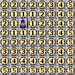

This figure shows some specific examples of squares that are 1,2,3,4, and 5 units away from the Wizard

[figure not shown]

### Lines

Due to the way that distances are defined in our maps, certain geometrical elements like lines are not as straightforward as one would expect. In the game map, a Line is:

- one of the shortest paths between two points (note that there can be several paths that meet this requirement!)
- composed of up to two straight segments: one in the horizontal or vertical direction, and another in a diagonal direction.

For any two points in the map, there will be one or two Lines that meet this definition.

This figure shows the simplest types of lines, composed of a single horizontal (1), vertical (2) or diagonal (3, 4) segment. Note that when two points can be joined by a single-segment Line, there will only be a single Line between these points.

[figure not shown]

This figure shows examples of two-segment lines. When two points can be joined by a two-segment line, there will always be two such lines between these points.

[figure not shown]

### Close and Area powers: Burst, Blast, Line

Area Burst

[figure not shown]

Range of Area Burst powers

[figure not shown]

Close Burst

[figure not shown]

### Line of Sight and Cover

Basic cover

[figure not shown]

Basic cover examples with attacking characters

[figure not shown]

Cover for large creatures

[figure not shown]

Examples of cover for large creatures with attacking characters

[figure not shown]

Basic Line of Sight

[figure not shown]

Examples of Line of Sight with enemy characters

[figure not shown]

Examples of Line of Sight with walls and doors

[figure not shown]

Combining Line of Sight, Cover, Superior Cover

[figure not shown]

### Light and Concealment

Light

[figure not shown]

more light

[figure not shown]

Yet more light

[figure not shown]

### Flanking

Flanking basics

[figure not shown]

Flanking for large creatures

[figure not shown]

## Combat Sequence

### Escalation

## Resource Management

### At-Will, Encounter and Daily powers

### Action Points

### Damage, Incapacitation and Healing

## Actions

### Reactions

## Movement

## Attacking

### Range and Targeting

### Hit Roll

#### Hit Modifiers

| Condition | Modifier |
| --- | --- |
| Defender grants Advantage | +2 |
| Defender has any Cover from Attacker | -2 |
| Defender has Superior Cover from Attacker | -3 |
| Defender has any Concealment from Attacker | -2 |
| Defender has Superior Concealment from Attacker | -3 |
| Attacker is Prone | -2 |
| Attacker has used Stand Up maneuver this turn | -2 |
| Attacker has used Shift maneuver this turn | -2 |
| Attacker has used Quick Draw maneuver this turn | -2 |
| Attack with Recharge weapon, unless Recharged | -2 |
| Ranged attack at Long Range | -2 |
| Charge attack | -1 |
| Opportunity Attack | + Reaction Modifier |

#### Critical Hits

### Damage Roll

#### Miss Damage

### Combat Conditions

#### List of Combat Conditions

List of combat conditions

- Blinded
  - Grants Advantage *(+2 to be hit)*
  - Cannot Flank
  - Treats other characters or objects as having Superior Concealment *(-5 to hit them)*.
  - No line of sight to other characters or objects
  - +1 Difficulty Category to Perception Skill Checks.
- Dazed
  - Cannot Flank
  - Cannot use Opportunity or Immediate Actions
  - Each turn, can use only:
    - One Minor Action, and
    - Either one Standard Action or one Move Action
- Dazzled
  - Treats all enemies as having Concealment *(-2 to hit them)* or, if already in Concealment, as having Superior Concealment *(an additional -3 to hit them)*.
- Deafened
  - Grants Advantage *(+2 to be hit)*
  - When using the Search combat maneuver, roll a Save. On a failed save, the maneuver has no effect
  - +1 Difficulty Category to Perception Skill Checks
- Dominated
  - Cannot take actions
  - When damaged, can roll a Save to end this condition
  - The dominating character can spend a move action to make the dominated character move its speed. *(This counts as forced movement)*
  - The dominating character can spend a standard action to make the dominated character use an at-will attack. *(This counts as a forced attack)*

Sidebar: Forced attack

Certain powers or effects allow one character to force an enemy to make an attack. Such attacks are considered forced attacks, and use the following rules:

If there are different attack powers that meet the requirement for the forced attack (e.g. basic attacks or at-will attacks), the character forcing the attack is aware of all available options and can choose any of them.

For the chosen attack power, the character forcing the attack can make any relevant decision, including (but not limited to) targets, area of effect, forced movement caused by the attack.

A character forced to make an attack cannot target himself with the forced attack.

Forced attacks ignore the marked condition. A character making a forced attack counts as not marked, for the purposes of that attack.

Forced attacks never trigger opportunity attacks.

- Grabbed
  - Cannot move
  - When grabbed, the character is pulled to a square adjacent to the grabbing character
  - The condition ends if at any time the grabbed character is not adjacent to the grabbing character
  - Grabbed character can use the Escape combat maneuver to end the condition. *(Move Action, roll save to end grab from one enemy)*
  - If forced movement would cause the grabbed character and the grabbing character to no longer be adjacent, the grabbed can roll a Save to end this condition. If the condition doesn’t end this way, the forced movement is negated
  - A character may be Grabbed by multiple enemies at a time.
- Helpless
  - Grants Advantage *(+2 to be hit)*
  - Melee Attacks against the character gain +10 Crit Range
- Hindered
  - -2 to Hit

- Immobilized
  - Cannot move
- Marked
  - -2 Hit on attacks that violate the mark (see sidebar)
  - A character may be Marked by multiple enemies at a time.

Sidebar: Violating marks

An attack by a Marked character violates a mark if it targets an enemy not marking the character. The following exceptions apply:

- If the attack targets multiple characters, and all enemies marking the character are already targeted, any additional targets do not violate the mark.
- If multiple attacks are made in sequence as part of the same attack power *(e.g. primary and secondary attacks)*, once all enemies marking the character have been targeted at least once, any additional targets do not violate the mark.
- If an attack originally does not violate the mark, and the attack targets are somehow changed by an enemy action or other effect, this does not cause the attack to violate the mark.
- If an attack originally does not violate the mark, and the attacker becomes Marked during the attack *(e.g. by an enemy reaction)*, this does not cause the attack to violate the mark.

**Compatibility Note**: Defender Aura

Some characters in compatible books have the Defender Aura power. The effect of this power should be replaced with the following:

“Enemies in the aura are Marked by you.”

**Compatibility Note**: Violating Marks

Any reference from compatible books to effects that trigger when a Marked character ‘makes an attack that does not include the marking character as a target’ should use the rules for violating marks described above.

- Petrified
  - Grants Advantage
  - Cannot take actions
  - Gains Resist.
- Prone
  - Condition lasts indefinitely until the character stands up *(e.g. by using the Stand Up combat maneuver: Move Action, end the prone condition, move 1, and become Hindered this turn)*
  - Cannot make any movement other than crawling *(e.g. by having a Crawl Speed, or by using the Crawl combat maneuver: Move Action, crawl 1)*
  - Hindered *(-2 Hit)*
  - Grants Advantage against melee attacks *(+2 to be hit)*
  - Against non-melee attacks, gains Cover *(-2 cover penalty to attack rolls)* or, if already in Cover, gains Total Cover *(an additional -3 cover penalty to attack rolls)*
- Exiled
  - When exiled, a character disappears from its current position. When the condition ends, the character reappears on this position or, if not possible, in the closest ground square of his choice, unless the exiling effect states otherwise.
  - Does not occupy a space.
  - No line of sight to and from other creatures or objects unless the exiling effect states otherwise.
  - No line of effect to and from other creatures or objects unless the exiling effect states otherwise.
- Restrained
  - Cannot move
  - Ignores forced movement
  - Grants Advantage *(+2 to be hit)*
  - Hindered *(-2 Hit)*
- Slowed
  - For each square moved, must spend an additional square of movement
- Stunned
  - Cannot attack
  - Cannot move
  - Can only take one action per turn
  - Cannot use Reactions
  - Grants Advantage *(+2 to be hit)*
- Swallowed
  - When swallowed, a character disappears from its current position. When the condition ends, the character reappears in a square of his choice as close as possible to the swallower.
  - Can spend a move action to make an Escape Check (see sidebar). If successful, condition ends.
  - Does not occupy a space.
  - Can only take one action per turn.
  - Only has line of effect and line of sight to and from the swallower, and other characters and objects swallowed by it.
  - The inside of the swallower, and swallowed characters and objects, are in total darkness unless otherwise specified. Swallowed characters can use any light source to illuminate the inside of the swallower and all characters and objects swallowed by it.
  - When using a burst or blast power while swallowed, the swallower and all characters and objects swallowed by it are included in the burst or blast.
- Unconscious
  - When a character falls unconscious, he is knocked prone.
  - When damaged, if the character has 1 or more remaining hit points after receiving the damage, the condition ends.
  - Helpless *(+2 to be hit, enemy melee attacks gain +10 Crit Range)*
  - Cannot take actions
  - Cannot see.
- Weakened
  - Damage dealt is halved
  - Healing granted or received is halved
  - Shield Points granted or received are halved

### Forced Movement

#### Push

Push a single unit

[figure not shown]

Push a single unit, showing Lines

[figure not shown]

Push multiple units

[figure not shown]

Push multiple units, showing Lines for path

[figure not shown]

Push single unit at range, showing Lines

[figure not shown]

Push multiple units at range, showing Lines

[figure not shown]

#### Pull

Pull at range

[figure not shown]

#### Slide

Slide multiple units, at range (1) and in melee (2)

[figure not shown]

## Combat Maneuvers

### Standard Maneuvers

### Improvised Maneuvers